# A quick analysis of Baltimore crime

I’m going to do a very simple analysis of Baltimore crime to show off R. We’ll use data downloaded from Baltimore City’s awesome open data site (this was downloaded a couple of years ago so if you download now, you will get different results).

### Getting data

- Arrest data: https://data.baltimorecity.gov/Crime/BPD-Arrests/3i3v-ibrt
- CCTV data: https://data.baltimorecity.gov/Crime/CCTV-Locations/hdyb-27ak

Let’s load the data:

```r
arrest_tab=read.csv("BPD_Arrests.csv", stringsAsFactors=FALSE)
cctv_tab=read.csv("CCTV_Locations.csv", stringsAsFactors=FALSE)

# these columns are mislabeled, so fix them
tmp=arrest_tab$sex
arrest_tab$sex=arrest_tab$race
arrest_tab$race=tmp
```

### Exploring data

```r
# dimension of table (data.frame)
dim(arrest_tab)
```

```
## [1] 104528     15
```

```r
# what are the columns
names(arrest_tab)
```

```
##  [1] "arrest"            "age"               "sex"
##  [4] "race"              "arrestDate"        "arrestTime"
##  [7] "arrestLocation"    "incidentOffense"   "incidentLocation"
## [10] "charge"            "chargeDescription" "district"
## [13] "post"              "neighborhood"      "Location.1"
```

```r
# what is the average arrest age?
mean(arrest_tab$age)
```

```
## [1] 33.19639
```

```r
# the range of arrest ages
range(arrest_tab$age)
```

```
## [1]  0 87
```

```r
# how many arrests per sex
table(arrest_tab$sex)
```

```
##
##           F     M
##     2 19431 85095
```

```r
# what are the most common offenses
head(sort(table(arrest_tab$incidentOffense),decreasing=TRUE))
```

```
##
##         Unknown Offense            87-Narcotics       4E-Common Assault
##                   38649                   24744                    6739
## 87O-Narcotics (Outside)     97-Search & Seizure                79-Other
##                    6515                    3670                    3461
```

```r
# range of arrests after removing those w/ age==0
range(arrest_tab$age[arrest_tab$age>0])
```

```
## [1]  8 87
```

Let’s see a table of arrests by sex and race

```r
table(sex=arrest_tab$sex,race=arrest_tab$race)
```

```
##    race
## sex           A     B     H     I     U     W
##         2     0     0     0     0     0     0
##   F     0    37 14663     0    34   183  4514
##   M     0   205 72605     1   184  1566 10534
```

A histogram of age

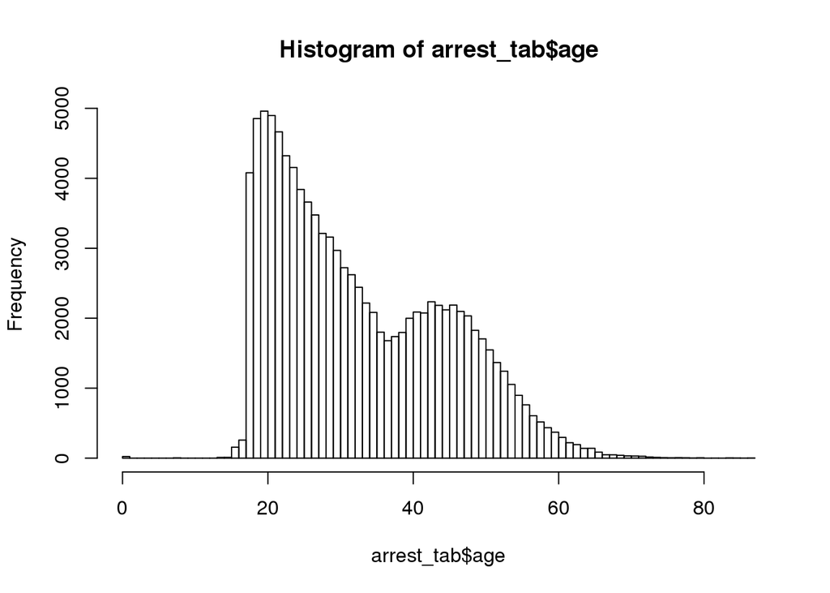

```r
hist(arrest_tab$age,nc=100)
```

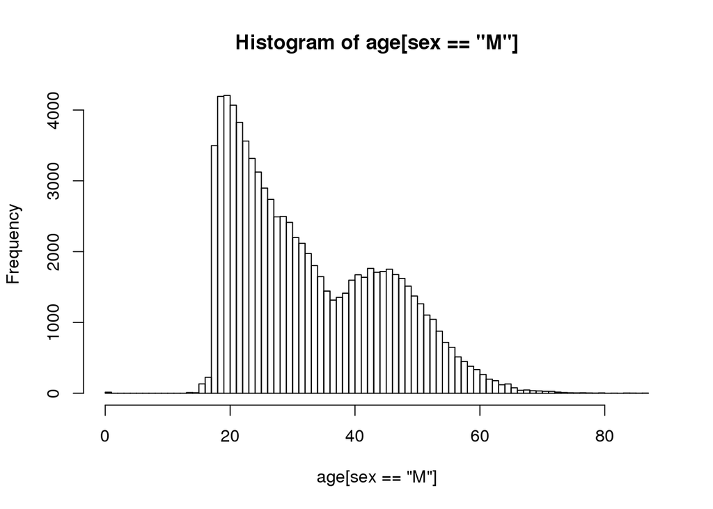

```r
with(arrest_tab,hist(age[sex=="M"],nc=100)) # males only
```

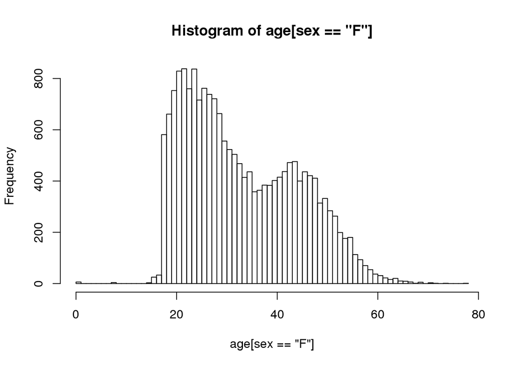

```r
with(arrest_tab,hist(age[sex=="F"],nc=100)) # females only
```

### Are males and females arrested at different ages on average?

Let’s take a look at how age depends on sex. Let’s plot age as a function of sex first (notice how we indicate that sex is a `factor`).

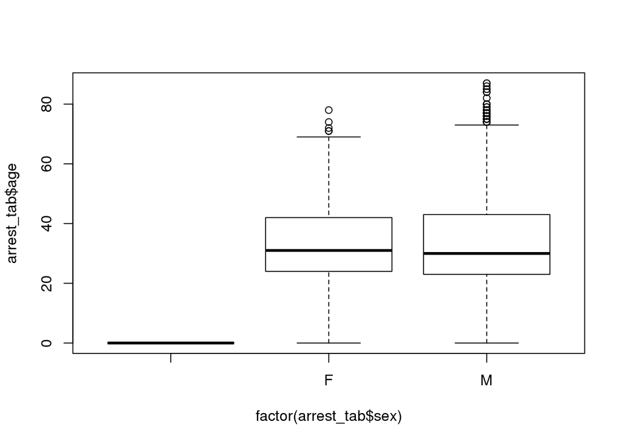

```r
plot(arrest_tab$age~factor(arrest_tab$sex))
```

One of the neat things about R is that statistical model building and testing is built-in. The model we use is $y_i=\beta_0+\beta_1 x_i$ where $y_i$ is age of sample (example) $i$ and $x_i$ is an indicator variable $x_i \in \{0,1\}$ with $x_i=1$ if the $i$-th record (example) is male. You can check that $\beta_1$ is the difference in mean age between females and males. We use the formula syntax to build a linear regression model.

```r
# let's ignore those records with missing sex
fit=lm(age~factor(sex),data=arrest_tab,subset=arrest_tab$sex %in% c("M","F"))
summary(fit)
```

```
##
## Call:
## lm(formula = age ~ factor(sex), data = arrest_tab, subset = arrest_tab$sex %in%
##     c("M", "F"))
##
## Residuals:
##     Min      1Q  Median      3Q     Max
## -33.388 -10.153  -3.153   9.612  53.847
##
## Coefficients:
##              Estimate Std. Error t value Pr(>|t|)
## (Intercept)  33.38778    0.08472 394.117   <2e-16 ***
## factor(sex)M -0.23432    0.09389  -2.496   0.0126 *
## ---
## Signif. codes:  0 '***' 0.001 '**' 0.01 '*' 0.05 '.' 0.1 ' ' 1
##
## Residual standard error: 11.81 on 104524 degrees of freedom
## Multiple R-squared:  5.958e-05,  Adjusted R-squared:  5.002e-05
## F-statistic: 6.228 on 1 and 104524 DF,  p-value: 0.01257
```

### Geographic distribution of arrests.

First we need to extract latitude and longitude from location, we’ll use some string functions to do this

```r
tmp=gsub("\\)","",gsub("\\(","",arrest_tab$Location))
tmp=strsplit(tmp,split=",")
arrest_tab$lon=as.numeric(sapply(tmp,function(x) x[2]))
arrest_tab$lat=as.numeric(sapply(tmp,function(x) x[1]))
```

Now let’s plot

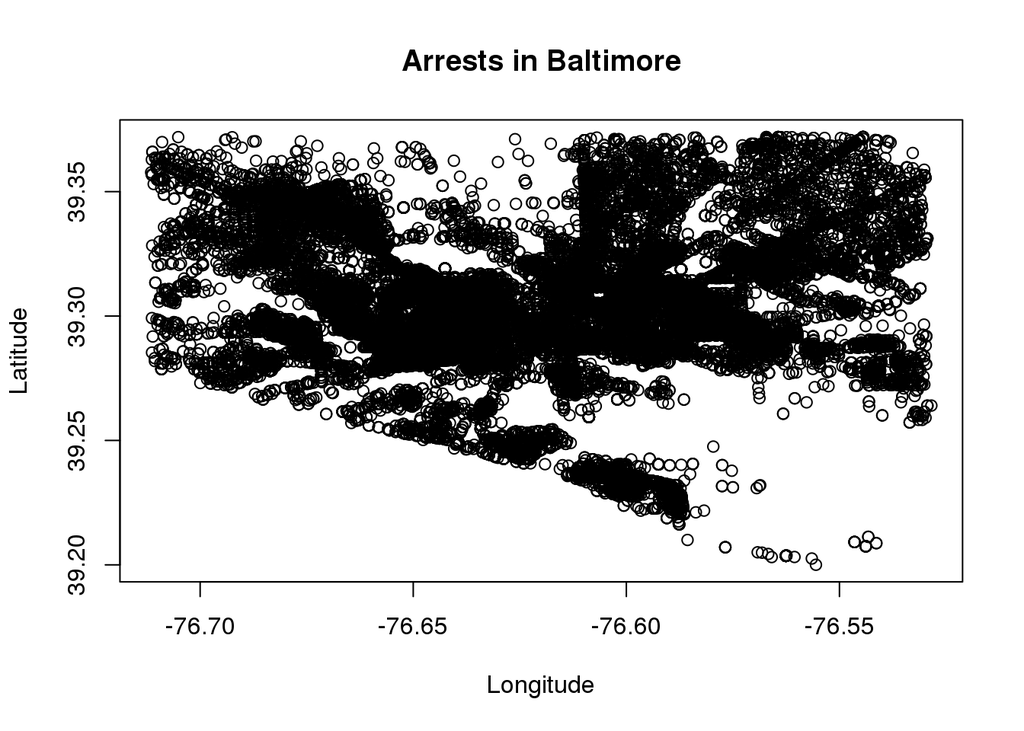

```r
plot(arrest_tab$lon, arrest_tab$lat, xlab="Longitude", ylab="Latitude", main="Arrests in Baltimore")
```

We can also use density estimates to make this nicer:

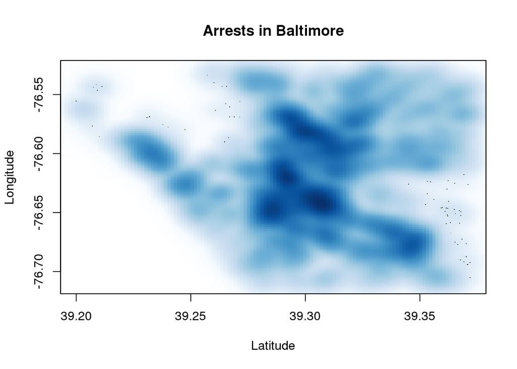

```r
smoothScatter(arrest_tab$lat, arrest_tab$lon, xlab="Latitude", ylab="Longitude", main="Arrests in Baltimore")
```

Let’s make this fancier using the `ggplot2` graphics systems and the `maps` package containing map data.

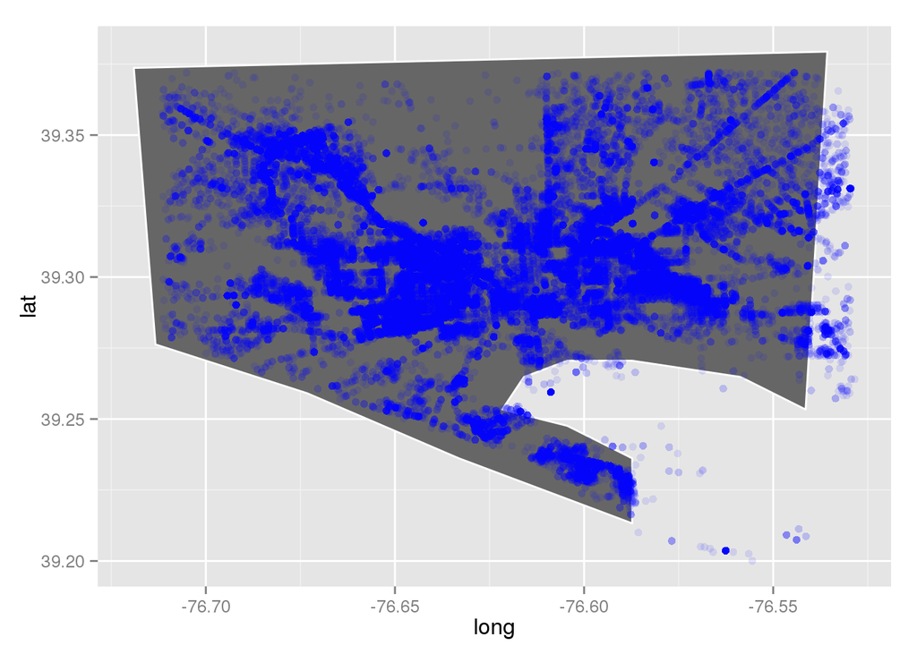

```r
library(maps)
library(ggplot2)

balto_map = subset(map_data("county", region="maryland"),subregion=="baltimore city")
plt=ggplot()
plt=plt+geom_polygon(data=balto_map,aes(x=long,y=lat),color="white",fill="gray40")
plt=plt+geom_point(data=arrest_tab,aes(x=lon,y=lat),color="blue",alpha=.1)
print(plt)
```

Now let’s add CCTV cameras.

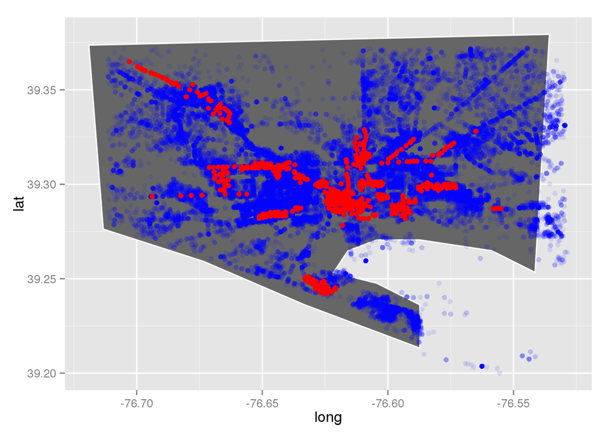

```r
tmp=gsub("\\)","",gsub("\\(","",cctv_tab$Location))
tmp=strsplit(tmp,split=",")
cctv_tab$lon=as.numeric(sapply(tmp,function(x) x[2]))
cctv_tab$lat=as.numeric(sapply(tmp,function(x) x[1]))

plt=ggplot()
plt=plt+geom_polygon(data=balto_map,aes(x=long,y=lat),color="white",fill="gray40")
plt=plt+geom_point(data=arrest_tab,aes(x=lon,y=lat),color="blue",alpha=.1)
plt=plt+geom_point(data=cctv_tab,aes(x=lon,y=lat),color="red")
print(plt)
```

### A challenge

Is there any relationship between the number of CCTV cameras and the number of arrests? Divide the city into a grid and plot the number of CCTV cameras vs. the number of arrests.

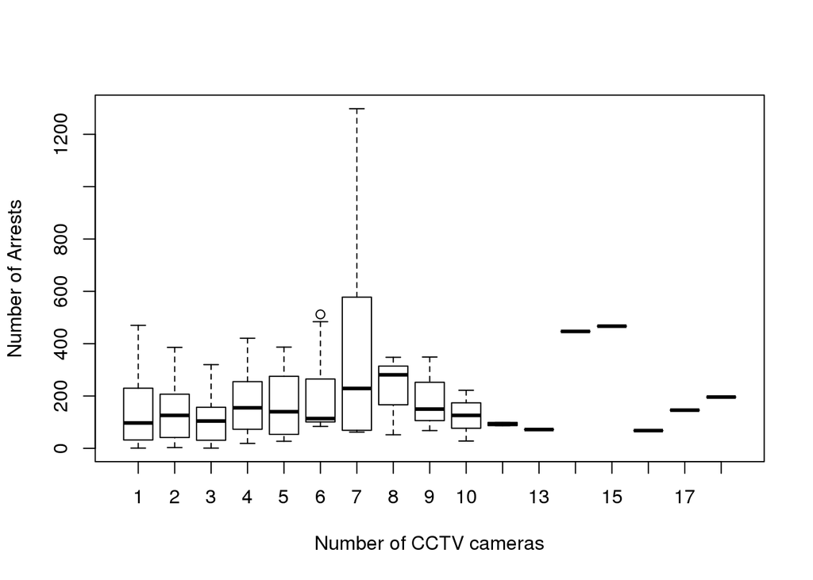

```r
# step 1: divide city intro grid for arrest data
# step 1a: find the range of latitude and longitude
latRange=range(arrest_tab$lat,na.rm=TRUE)
lonRange=range(arrest_tab$lon,na.rm=TRUE)

# step 1b: discretize latitude into 50 bins
latGrid=seq(min(latRange),max(latRange),len=50)
latFactor=cut(arrest_tab$lat,breaks=latGrid)

# now longitude
lonGrid=seq(min(lonRange),max(lonRange),len=50)
lonFactor=cut(arrest_tab$lon,breaks=lonGrid)

# step 1c: make a factor indicating geographic grid location
gridFactor=factor(paste(lonFactor,latFactor,sep=":"))

# step 2: do the same for the cctv data
latFactor=cut(cctv_tab$lat,breaks=latGrid)
lonFactor=cut(cctv_tab$lon,breaks=lonGrid)
cctvGridFactor=factor(paste(lonFactor,latFactor,sep=":"))

arrestTab=table(gridFactor)
cctvTab=table(cctvGridFactor)
m=match(names(cctvTab),names(arrestTab))
plot(arrestTab[m]~factor(cctvTab),xlab="Number of CCTV cameras", ylab="Number of Arrests")
```

### Extra analyses

As part of Project 1 you will add to this analysis. Please use the following template:

What question are you asking?:

What is the code you use to answer it?:

[figure not shown]

```r
plot(1:10,1:10)
```

```r
# code goes here
```

What did you observe?